# QSS4.5.1課題

[佐藤 慧](https://keisato0.github.io/)

2020年7月18日

# はじめに

問題に取り組む前に，ライブラリとデータセットを読み込む

```r
library(tidyverse)
library(magrittr)
library(patchwork)

# qssパッケージのインストールはqss公式サイト参照
library(qss)
data(intrade08)
data(intrade12)
data(pres08)
data(pres12)
data(polls08)
data(polls12)
```

# 問題1：市場予測の精度

```r
# 2008年 ---------------------------------------------------------------
# 市場予測
intrade08 %>%
  filter(day == "2008-11-03") %>%
  select(state, PriceD, PriceR) %>%
  mutate(expected_winner = case_when(
    PriceD < PriceR ~ "McCain",
    PriceR < PriceD ~ "Obama"
  )
  ) -> expected_market_08

# 世論調査
polls08 %>%
  group_by(state) %>%
  filter(middate == max(middate)) %>%
  summarise(Obama_poll = mean(Obama),
            McCain_poll = mean(McCain)) %>%
  mutate(expected_winner_poll= case_when(
    Obama_poll > McCain_poll ~ "Obama",
    Obama_poll < McCain_poll ~ "McCain"
  )) %>%
  data.frame() -> expected_poll_08

# 実際の結果
pres08 %>%
  select(state, Obama, McCain) %>%
  mutate(winner = case_when(
    Obama < McCain ~ "McCain",
    McCain < Obama ~ "Obama"
  )) -> results_08

# 市場予測が外れた州
left_join(expected_market_08, expected_poll_08,
          by = "state") %>%
  left_join(., results_08, by = "state") %>%
  filter(expected_winner != winner)
```

```
##   state PriceD PriceR expected_winner Obama_poll McCain_poll
## 1    IN   39.0   62.2          McCain         44          49
## 2    MO   55.6   48.0           Obama         47          46
##   expected_winner_poll Obama McCain winner
## 1               McCain    50     49  Obama
## 2                Obama    48     49 McCain
```

```r
# 世論調査が外れた州
left_join(expected_market_08, expected_poll_08,
          by = "state") %>%
  left_join(., results_08, by = "state") %>%
  filter(expected_winner_poll != winner)
```

```
##   state PriceD PriceR expected_winner Obama_poll McCain_poll
## 1    IN   39.0   62.2          McCain         44          49
## 2    MO   55.6   48.0           Obama         47          46
## 3    NC   61.4   39.5           Obama         48          49
##   expected_winner_poll Obama McCain winner
## 1               McCain    50     49  Obama
## 2                Obama    48     49 McCain
## 3               McCain    50     49  Obama
```

```r
# 2012年 ---------------------------------------------------------------

# 市場予測
intrade12 %>%
  filter(day == "2012-11-05") %>%
  select(state, PriceD, PriceR) %>%
  replace_na(replace = list(PriceD = 0, PriceR = 0)) %>%
  mutate(expected_winner = case_when(
    PriceD < PriceR ~ "Romney",
    PriceR < PriceD ~ "Obama"
  )) -> expected_market_12

# 世論調査
polls12 %>%
  group_by(state) %>%
  filter(middate == max(middate)) %>%
  summarise(Obama_poll = mean(Obama),
            Romney_poll = mean(Romney)) %>%
  mutate(expected_winner_poll= case_when(
    Obama_poll > Romney_poll ~ "Obama",
    Obama_poll < Romney_poll ~ "Romney"
  )) %>%
  data.frame() -> expected_poll_12

# 結果
pres12 %>%
  select(state, Obama, Romney) %>%
  mutate(winner = case_when(
    Obama < Romney ~ "Romney",
    Romney < Obama ~ "Obama"
  )) -> results_12

# 市場予測が外れた州
left_join(expected_market_12, expected_poll_12,
          by = "state") %>%
  left_join(., results_12, by = "state") %>%
  filter(expected_winner != winner)
```

```
##   state PriceD PriceR expected_winner Obama_poll Romney_poll
## 1    FL   33.8   71.4          Romney         48    48.33333
##   expected_winner_poll Obama Romney winner
## 1               Romney    50     49  Obama
```

```r
# 世論調査が外れた州
left_join(expected_market_12, expected_poll_12,
          by = "state") %>%
  left_join(., results_12, by = "state") %>%
  filter(expected_winner_poll != winner)
```

```
##   state PriceD PriceR expected_winner Obama_poll Romney_poll
## 1    FL   33.8   71.4          Romney         48    48.33333
##   expected_winner_poll Obama Romney winner
## 1               Romney    50     49  Obama
```

#### コメント

2008年については，市場予測が外れたのはインディアナ，ミズーリの2州，世論調査が外れたのはこれらにノースカロライナ州を加えた3州であった。予測が当たった州の数をもって予測の精度とするならば市場予測のほうが精度が高い。

これらの州はいずれも1ポイント差で勝敗が決まる接戦であった。世論調査は，勝者を当てられなかったとはいえ接戦であったことは予想している(最大でも5ポイント差)。一方，賭博市場では勝敗にかなりの差が出ると予想している。予測を外した州の得票率の差の予測においては世論調査のほうが正確だった。

2012年は市場予測，世論調査どちらも1ポイント差の接戦で民主党が勝ったフロリダ州で共和党が勝つと予測した以外は勝者を的中させている。ただし，こちらも前回同様，世論調査は接戦(0.3ポイント差で共和党勝利)を予測したのに対し賭博市場では共和党が民主党の2倍以上の取引量があり，結果と大きく異なった。

# 問題2-3：市場予測プロット

## 問題2：1日ごとの値

```r
intrade08 %>%
  filter(as.Date("2008-11-04") - 90 <= day & day <= "2008-11-04") %>%
  select(state, day, PriceD) %>%
  left_join(.,
            pres08 %>% select(state, EV),
            by = "state"
            ) %>%
  mutate(expectedD = (PriceD/100)*EV) %>%
  group_by(day) %>%
  summarise(expectedD = sum(expectedD)) %>%
  data.frame() %>%
  ggplot(mapping = aes(x = day, y = expectedD)) +
  geom_point() +
  geom_line() +
  scale_y_continuous(limits = c(200, 400)) +
  annotate("point",
           x = as.Date("2008-11-04"),
           y = 365,
           col = rgb(1, 0, 0, 0.5)
           ) +
  ggtitle("Expectation in Each Day") +
  labs(x = "Day", y = "Expected Polls") -> expectedD_graph
```

## 問題3：7日移動平均

```r
intrade08 %>%
  filter(as.Date("2008-11-04") - 96 <= day & day <= "2008-11-04") %>%
  select(state, day, PriceD) %>%
  arrange(state, day) %>%
  mutate(avgD_7days = NA) -> trade_log

for (i in 7:nrow(trade_log)) {
  trade_log$avgD_7days[i] <- sum(trade_log$PriceD[(i-6):i]) / 7
  }

trade_log %>%
  filter(as.Date("2008-11-04") - 90 <= day) %>%
  left_join(.,
            pres08 %>%
              select(state, EV),
            by = "state"
  ) %>%
  mutate(expectedD = (avgD_7days/100)*EV) %>%
  group_by(day) %>%
  summarise(expectedD = sum(expectedD)) %>%
  data.frame() %>%
  ggplot(mapping = aes(x = day, y = expectedD)) +
  geom_point() +
  geom_line() +
  scale_y_continuous(limits = c(200, 400)) +
  ggtitle(" Moving Avarage") +
  labs(x = "Day", y = "Expected Polls") +
  annotate("point",
           x = as.Date("2008-11-04"),
           y = 365,
           col = "red"
  )  -> expectedD_graph_mavg
```

## プロット

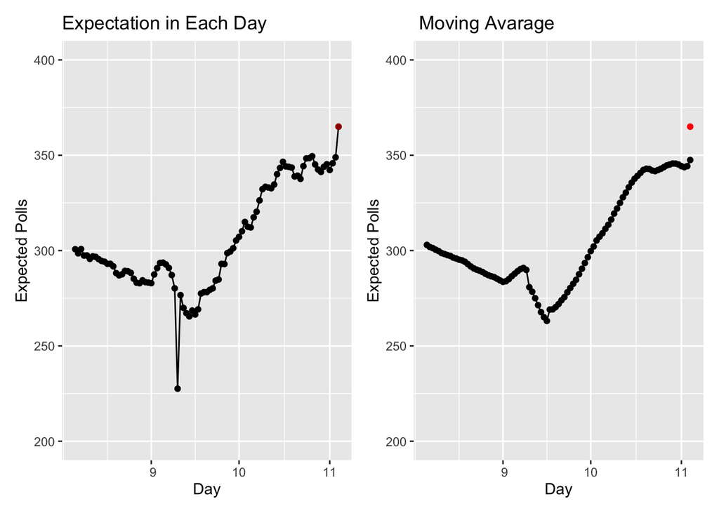

```r
expectedD_graph + expectedD_graph_mavg
```

#### コメント

上の左の図はややわかりにくいが，選挙当日の予測得票数は約364で，実際の365に非常に近い。そのため2つの点が重なって図が見にくくなっている。1日ごとの予測値で見ると投票日が近づくにつれ市場予測は実際の得票数に近づいている。

7日移動平均は1日ごとの値を用いた場合に比べ外れ値の影響が小さいので変動が全体的に小さい。

# 問題4：世論調査予測プロット

あとから読み返したら冗長な箇所が多かったが，そのまま掲載する。

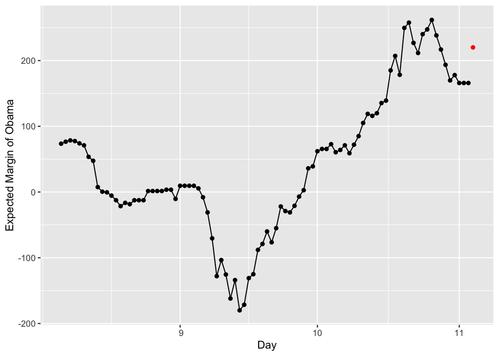

```r
state_names <- unique(polls08$state)
state_names <- state_names[order(state_names)]

polls08 %>%
  select(-Pollster) %>%
  arrange(state, middate) %>%
  mutate(margin = Obama -McCain) %>%
  select(-Obama, -McCain) %>%
  left_join(.,
            data.frame(
              state = state_names,
              states_number = 1:length(state_names)
              ),
            by = "state"
  ) -> reference

data.frame(
  state_number = rep(1:length(state_names), each = 90),
  number_within_state = rep(1:90, times = 51),
  date = rep(
  seq(as.Date("2008-08-06"), as.Date("2008-11-03"), by = "day"),
  length(state_names),
         ),
  expected_margin = rep(NA)
  ) -> results


for (i in 1:51) {
for (j in 1:90) {
  date <- results$date[results$state_number == i & results$number_within_state == j]

  diffdays <- date - reference$middate[reference$states_number == i]
  diffdays <- as.vector(diffdays)
  diffdays <- min(diffdays[0 <= diffdays])

  poll_day <- date - diffdays
  objective <- mean(reference$margin[reference$states_number == i & reference$middate == poll_day])

  results$expected_margin[results$state_number == i & results$number_within_state == j] <- objective
}
}

results %>%
  select(date, expected_margin) %>%
  group_by(date) %>%
  summarise(expected_margin = sum(expected_margin)) %>%
  data.frame() %>%
  ggplot(mapping = aes(x = date, y = expected_margin)) +
  geom_point() +
  geom_line() +
  labs(x = "Day", y = "Expected Margin of Obama") +
  # annotate("text", x = as.Date("2008-10-17"), y = -100,
  #          size = 4.5,
  #          label = "The actual margin was 220(indicated in red).")
  annotate("point", x = as.Date("2008-11-04"), y = 220,
           col = "red")
```

#### コメント

各日の最新時点の世論調査の，民主党(オバマ)の勝利マージンの予測値の推移をプロットしたもの。概形は上の二つのグラフに似ている。9月半ばから10月半ばにかけての1ヶ月に世論がオバマ支持に傾いていったことがわかる。

# 問題5-6：勝利マージンの回帰分析

## 問題5：2008

```r
# 取引市場データを用いた回帰
options(scipen = 100)

intrade08 %>%
  filter(day == "2008-11-03") %>%
  select(state, PriceD, PriceR) %>%
  left_join(., pres08 %>% select(state, Obama, McCain, EV),
            by = "state") %>%
  mutate(expected_margin =
           (PriceD / 100) * EV - (PriceR / 100) * EV,
         actual_margin = Obama - McCain
         ) -> margin_for_regression

library(gtsummary)
margin_for_regression %>%
  lm(formula = actual_margin ~ expected_margin) %>% tbl_regression() -> lm_market_08

# 世論調査を用いた回帰

polls08 %>%
  group_by(state) %>%
  filter(middate == max(middate)) %>%
  select(state, Obama, McCain) %>%
  rename(Obama_poll = Obama, McCain_poll = McCain) %>%
  left_join(., pres08 %>% select(-state.name), by = "state") %>%
  mutate(expected_margin =
           (Obama_poll / 100) * EV - (McCain_poll / 100) * EV,
         actual_margin = Obama - McCain) -> polls08_for_regression

polls08_for_regression %>%
  lm(formula = actual_margin ~ expected_margin) %>% tbl_regression() -> lm_poll_08
```

## 問題6：2012

```r
# 取引市場データを用いた回帰

intrade12 %>%
  filter(day == "2012-11-05") %>%
  select(state, PriceD, PriceR) %>%
  left_join(., pres12 %>% select(state, Obama, Romney, EV),
            by = "state") %>%
  na.omit() %>%
  mutate(expected_margin =
           (PriceD / 100) * EV - (PriceR / 100) * EV,
         actual_margin = Obama - Romney
  ) -> margin_for_regression

margin_for_regression %>%
  lm(formula = actual_margin ~ expected_margin) %>% tbl_regression() -> lm_market_12

# 世論調査を用いた回帰

polls12 %>%
  group_by(state) %>%
  filter(middate == max(middate)) %>%
  select(state, Obama, Romney) %>%
  rename(Obama_poll = Obama, Romney_poll = Romney) %>%
  left_join(., pres12, by = "state") %>%
  mutate(expected_margin =
           (Obama_poll / 100) * EV - (Romney_poll / 100) * EV,
         actual_margin = Obama - Romney) -> polls12_for_regression

polls12_for_regression %>%
  lm(formula = actual_margin ~ expected_margin) %>% tbl_regression() -> lm_poll_12
```

## 回帰分析表

```r
tbl_merge(tbls = list(lm_market_08, lm_poll_08, lm_market_12, lm_poll_12),
          tab_spanner = c("**Market 2008**", "**Polls 2008**", "**Market 2012**", "**Polls 2012**"))
```

| **Characteristic** | **Market 2008** **Beta** | **Market 2008** **95% CI**<sup>1</sup> | **Market 2008** **p-value** | **Polls 2008** **Beta** | **Polls 2008** **95% CI**<sup>1</sup> | **Polls 2008** **p-value** | **Market 2012** **Beta** | **Market 2012** **95% CI**<sup>1</sup> | **Market 2012** **p-value** | **Polls 2012** **Beta** | **Polls 2012** **95% CI**<sup>1</sup> | **Polls 2012** **p-value** |
| --- | --- | --- | --- | --- | --- | --- | --- | --- | --- | --- | --- | --- |
| expected_margin | 0.99 | 0.54, 1.4 | <0.001 | 4.8 | 2.8, 6.8 | <0.001 | 0.87 | 0.45, 1.3 | <0.001 | 6.2 | 4.5, 7.8 | <0.001 |

<sup>*1*</sup> CI = Confidence Interval

## 散布図プロット

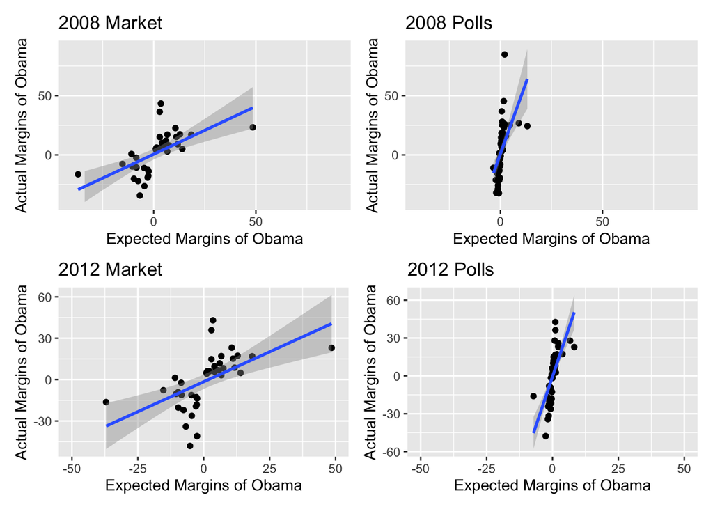

#### コメント

2008年，2012年ともに世論調査は市場予測よりもばらつきが小さい。また市場予測と世論調査とで回帰係数が大きく異なる。市場予測では係数は0.99と0.87だが世論調査では4.8と6.2である。つまり世論調査でのオバマの勝利マージンの1ポイント分の増加は実際の勝利マージン5-6ポイント分の増加を予測していた。

散布図のスクリプトは以下の通り。

```r
# 市場2008
margin_for_regression %>%
  ggplot(mapping = aes(x = expected_margin, y = actual_margin)) +
  geom_jitter() +
  scale_x_continuous(limits = c(-40, 90)) +
  scale_y_continuous(limits = c(-40, 90)) +
  labs(title = "2008 Market",
       x = "Expected Margins of Obama",
       y = "Actual Margins of Obama") +
  geom_smooth(method = "lm") -> plot_market_08

# 世論調査2008
polls08_for_regression %>%
  ggplot(mapping = aes(x = expected_margin, y = actual_margin)) +
  geom_jitter() +
  scale_x_continuous(limits = c(-40, 90)) +
  scale_y_continuous(limits = c(-40, 90)) +
  labs(title = "2008 Polls",
       x = "Expected Margins of Obama",
       y = "Actual Margins of Obama") +
  geom_smooth(method = "lm") -> plot_polls_08

# 市場2012
margin_for_regression %>%
  ggplot(mapping = aes(x = expected_margin, y = actual_margin)) +
  geom_jitter() +
  scale_x_continuous(limits = c(-50, 50)) +
  # scale_y_continuous(limits = c(-40, 90)) +
  labs(title = "2012 Market",
       x = "Expected Margins of Obama",
       y = "Actual Margins of Obama") +
  geom_smooth(method = "lm") -> plot_market_12

# 世論調査2012
polls12_for_regression %>%
  ggplot(mapping = aes(x = expected_margin, y = actual_margin)) +
  geom_jitter() +
  scale_x_continuous(limits = c(-50, 50)) +
  # scale_y_continuous(limits = c(-40, 90)) +
  labs(title = "2012 Polls",
       x = "Expected Margins of Obama",
       y = "Actual Margins of Obama") +
  geom_smooth(method = "lm") -> plot_polls_12

(plot_market_08 + plot_polls_08) /
(plot_market_12 + plot_polls_12)
```